# PROCRASTINATION - A GLOBAL ANALYSIS

```r
  "Post Grad Physician"="Physician - Post Grad",
  "Postdoc"="Student - Post Doctoral",
  "Postdoctoral Researcher"="Researcher - Post Doctoral",
  "pr and communications firm owner"="Public Relations",
  "President Nongovernmental organization"="President - NGO",
  "president/CEO"="CEO",
  "Probation Supervisor"="Probation officer",
  "Process Engineer"="Engineer - Process",
  "Procrastinator"="*Missing*",
  "Produce Associate"="Grocery Store - produce associate",
  "producer"="Film - Producer",
  "Production Operations Support Analyst"="Operations - Production Support Analyst",
  "Professional Organizer"="Organizer - professional",
  "Professional Soccer Player"="Soccer Player - Professional",
  "Programmer Analyst"="IT Software engineer",
  "Programmer"="IT Software engineer",
  "Programmer/Developer"="IT Software engineer",
  "Programmer/Software Analyst"="IT Software engineer",
  "Proposal Director"="Contract/Proposal - Director",
  "psychologis"="Psychologist",
  "P-T College Faculty & P-T Self-Employed"="Professor",
  "real estate broker"="Realtor",
  "Real estate developer"="Real Estate Developer",
  "real estate"="Real estate agent",
  "realtor"="real estate agent",
  "Reasearch assistant"="Research Assistant",
  "Receptionist"="Receptionist",
  "Recreational Staff"="Recreational Staff",
  "Regional Sales Manager"="Sales - Manager",
  "Registered Respiratory Therapist"="Respiratory - Therapist",
  "Residence Don"="Residential Services - Supervisor",
  "resident physician"="Physician",
  "restaurant mgr / student / and looking f"="Restaurant Operations - Mgr",
  "Retail / artist /writer"="Retail",
  "retired/adjunct"="Retired",
  "RN - Medical Sales"="Sales - medical",
  "RN"="Nurse - RN",
  "rocket scientist"="Scientist - Rocket",
  "s"="*Missing*",
  "School Counselor"="Counselor - School",
  "school"="Student",
  "Science writing intern"="Writer - Science (intern)",
  "secretary"="Admin Assistant",
  "Self employed Public Relations"="Public Relations",
  "Self Employed"="Business Owner / Self Employed",
  "self employeed"="Business Owner / Self Employed",
  "Self-Employed / personal trainer / stren"="Personal Trainer",
  "Self-employed Family Therapist"="Therapist - Family",
  "self-employed freelance writer/author"="Writer/Author - Freelance",
  "self-employed Photographer"="Photographer",
  "self-employed translator"="Translator",
  "Self-employed writer/editor"="Writer/Author - Freelance",
  "selfemplyed renovator"="Renovator",
  "Senior Consultant Programmer/Analyst"="IT Programmer - Consultant",
  "senior consultant"="Consultant Sr.",
  "Senior Human Resources Consultant"="HR Consultant",
  "Senior Policy Advisor"="Policy Advisor",
  "senior project manager"="Project Manager",
  "Senior Records Analyst"="Records Analyst",
  "Senior Staff Writer"="Writer",
  "Senior Systems Analyst"="IT Systems Analyst",
  "Server"="Restaurant - Food Server",
  "Service Registrar/English Instructor"="Teacher",
  "Shipping/receiving/warehouse mgnt"="Warehousing",
  "Software analyst"="IT Software engineer",
  "Software Developer"="IT Software engineer",
  "Software engineer"="IT Software engineer",
  "Software Pro"="IT Software professional",
  "Software Sales"="Sales - Software",
  "Software trainer"="Training -  Software",
  "Special Projects Editor"="Editor - Special Projects",
  "specialist"="*Ambiguous*",
  "Speech and language Assistant"="language and Speech Assistant",
  "Sr. Drug Safety Associate"="Drug Safety",
  "Stay-at-home dad"="home-maker",
  "Studey"="Student",
  "supervising program development speciali"="Program Development Specialist",
  "supervisor shelderd workshop for handcap"="Social Worker - Handicap",
  "Supervisor"="*Ambiguous*",
  "Surgical Resident"="Surgeon - resident",
  "System Analyst"="IT Systems Analyst",
  "system manager"="IT Systems Analyst",
  "Systems Analyst"="IT Systems Analyst",
  "Systems Programmer/Analyst"="IT Systems Analyst",
  "Tech Support"="Technical Support",
  "Technology (CTO)"="IT - CTO",
  "Technology Curriculum Developer Science"="Technology Curriculum Developer Science",
  "Temp"="*Ambiguous*",
  "temporary office"="*Ambiguous*",
  "Test Item Writer (Self-employed)"="Writer - Testing",
  "Tour Guide"="Tour Guide",
  "Town Planner"="Planner - Town",
  "Traffic Reporter-Radio"="Reporter - Traffic",
  "trainee"="*Ambiguous*",
  "university faculty"="Professor",
  "University Staff"="Academic - Administration",
  "Urban Planner/Economic Development Plann"="Planner - Urban",
  "'Utterly shiftless arts student'... at p"="Student",
  "Vetrans Representative"="Veterans Representative",
  "vidoe"="Videographer",
  "VMD"="*Ambiguous*",
  "VP Scientific Affairs / pharmaceutical c"="Scientific Affairs - VP"
   ))
```

**—————————————————————————————————————————————————————————————————**

RENAME VALUES IN THE FIELD “EDU” TO MEANINGFUL NAMES AND LOAD TO A NEW COLUMN NAMED “EDUCATIONALT”

**—————————————————————————————————————————————————————————————————**

```r
# Format and expand on the Education abbreviations to meaningful values
ELSE <- TRUE
procrastinate <- procrastinate %>%
                            mutate(EducationAlt = case_when(
                                                            .$Education == "ma"      ~ "Masters",
                                                            .$Education == "deg"     ~ "Degree",
                                                            .$Education == "dip"     ~ "Diploma",
                                                            .$Education == "grade"   ~ "Elementary School",
                                                            .$Education == "high"    ~ "High School",
                                                            .$Education == "lthigh"  ~ "Left High School",
                                                            .$Education == "ltuni"   ~ "Left University",
                                                            .$Education == "phd"     ~ "PhD",
                                                            ELSE                     ~ "*Missing*"
                                                           )
                                    )
```

**—————————————————————————————————————————————————————————————————**

CLEAN OTHER FIELDS AS APPROPRIATE.

**—————————————————————————————————————————————————————————————————**

```r
# Replace missing values in "Gender" with an explicit "*Missing*"
procrastinate$Gender <- gsub("^$", "*Missing*", procrastinate$Gender)

# Remove the word "Kids", replace blanks with "*Missing*"" and capitalize first letter
procrastinate$Kids <- gsub(" Kids","",
                            gsub("^$","*Missing*",procrastinate$Kids ))


# Replace 0 & blanks with "*Missing*" and capitalize first letter
procrastinate$WrkStatus <- gsub("^0$","*Missing*",
                                gsub("^$","*Missing*", procrastinate$WrkStatus))


# Replace 999 & blanks with "*Missing*" and convert to integer and round
procrastinate$YearsInPos <- gsub("^999$",NA, # Replace 999 to "*Missing*"
                            gsub("^$" ,NA,
                           round(as.integer(procrastinate$YearsInPos), digits = 0 )))

# Replace 0 and blanks to "*Missing*"
procrastinate$MaritalStat <- gsub("0","*Missing*",
                                 gsub("^$" , "*Missing*", procrastinate$MaritalStat))

# Replace blanks, 0 & 8 with "*Missing*"
procrastinate$CommSize <- gsub("^$" , "*Missing*", procrastinate$CommSize)

procrastinate$CommSize <- plyr::revalue(procrastinate$CommSize,
                                        c("0" = "*Missing*",
                                          "8" = "*Missing*"))

# Replace 0 with "*Missing*"
procrastinate$Country <- gsub("0","*Missing*",
                                  gsub("^$" , "*Missing*", procrastinate$Country))

# Set Male=1 and Female=2 in field = "Sons"
procrastinate$Sons <- gsub("Female", "^2$",
                      gsub("Male", "^1$", procrastinate$Sons))

# Convert fields to integer as required
procrastinate$Sons <- as.integer(procrastinate$Sons)
# Clean up "Self Procrastinator" field by setting blanks to an explicit "*Missing*"
procrastinate$SelfProcrast <- gsub("^$" , "*Missing*", procrastinate$SelfProcrast)

# Clean up the field "Others say you are a procrastinator" by replacing 0s, 4s & "blanks" with "*Missing*"
procrastinate$OthrProcrast <- gsub("^$" , "*Missing*", procrastinate$OthrProcrast)

procrastinate$OthrProcrast <- plyr::revalue(procrastinate$OthrProcrast,
                                        c("^0$" = "*Missing*",
                                          "^4$" = "*Missing*"))
# format Income to dollar currency
# HDIMerged$IncomeCurr <- to_currency( HDIMerged$Income, currency_symbol = "$", symbol_first = TRUE,
#                                     group_size = 3, group_delim = ",", decimal_size = 0,
#                                     decimal_delim = ".")

# Change to "Title" case
procrastinate$Kids           <- str_to_title(procrastinate$Kids, locale = "en") # Replace blanks with "*Missing*"
procrastinate$SelfProcrast   <- str_to_title(procrastinate$SelfProcrast, locale = "en") # Change to "Title" case
procrastinate$OthrProcrast   <- str_to_title(procrastinate$OthrProcrast, locale = "en") # Change to "Title" case
procrastinate$OccupatnAlt    <- str_to_upper(procrastinate$OccupatnAlt, locale = "en") # Change to UPPER case
procrastinate$WrkStatus      <- str_to_title(procrastinate$WrkStatus, locale = "en")
```

**—————————————————————————————————————————————————————————————————**

MERGE THE WEBSCRAPE AND PROCRASTINATE DATA FRAMES ON COUNTRY DOING A LEFT JOIN ON WEBSCRAPE.

**—————————————————————————————————————————————————————————————————**

```r
# Let's trim all whitespace in the country field of the webscrape
HDI_raw$Country <- str_trim(HDI_raw$Country) # Trim whitespace on left and right of value
procrastinate$Country <- str_trim(procrastinate$Country) # Trim whitespace on left and right of value

# Rectify some name spellings in the countries between the web data and the procrastinate data
procrastinate$Country <- plyr::revalue(procrastinate$Country,
                                            c("Columbia" = "Colombia",
                                              "Isreal"   = "Israel"))

# Merge the two data sets to a single data set
HDIMerged <- merge(procrastinate, HDI_raw, by = "Country", all.x = TRUE)

# Replace NA with explicit *Missing* in HDI category
HDIMerged$HDICategory[is.na(HDIMerged$HDICategory)] <- "*Missing*"
```

**—————————————————————————————————————————————————————————————————**

**PRELIMINARY DATA ANALYSIS**

*For the purpose of this analysis we have eliminated all participants under 18 years of age. This will permit a focus on primarily employment eligible individuals. Furthermore, we have also excluded all participants 80 years and above for a similar purpose.The intention is not to skew our analysis in any way with bias from participants 18 and below and 80 and above.*

**—————————————————————————————————————————————————————————————————**

**DESCRIPTIVE STATISTICS OF KEY FACTORS**

- AGE
- INCOME
- HDI

**—————————————————————————————————————————————————————————————————**

```r
# create data frames for each of the 3 variables
AGE    <- HDIMerged$Age
INCOME <- HDIMerged$Income
HDI    <- HDIMerged$HDI

# Combine them inot a single data frame
d <- data.frame(AGE,INCOME, HDI )

# Generate the descriptive statistics
summary(d)
```

```
##       AGE            INCOME            HDI
##  Min.   : 7.50   Min.   :     0   0.920  :3143
##  1st Qu.:28.00   1st Qu.: 15000   0.909  : 184
##  Median :32.50   Median : 45000   0.939  : 117
##  Mean   :37.43   Mean   : 58916   0.624  :  78
##  3rd Qu.:45.00   3rd Qu.: 67500   0.887  :  67
##  Max.   :80.00   Max.   :250000   (Other): 428
##  NA's   :71      NA's   :548      NA's   : 247
```

**—————————————————————————————————————————————————————————————————**

**SURVEY MEANS**

- DP
- GP
- AIP
- SWLS

**—————————————————————————————————————————————————————————————————**

```r
DP   <- HDIMerged$DPMean
GP   <- HDIMerged$GPMean
AIP  <- HDIMerged$AIPMean
SWLS <- HDIMerged$SWLSMean

d <- data.frame(DP,GP, AIP, SWLS )

summary(d)
```

```
##        DP              GP             AIP             SWLS
##  Min.   :0.800   Min.   :1.000   Min.   :1.000   Min.   :1.000
##  1st Qu.:2.000   1st Qu.:2.750   1st Qu.:2.330   1st Qu.:2.600
##  Median :2.600   Median :3.250   Median :2.930   Median :3.200
##  Mean   :2.598   Mean   :3.227   Mean   :2.936   Mean   :3.205
##  3rd Qu.:3.200   3rd Qu.:3.750   3rd Qu.:3.530   3rd Qu.:3.800
##  Max.   :6.000   Max.   :5.000   Max.   :5.000   Max.   :5.000
```

**—————————————————————————————————————————————————————————————————**

**HISTOGRAM: AIP MEAN**

**—————————————————————————————————————————————————————————————————**

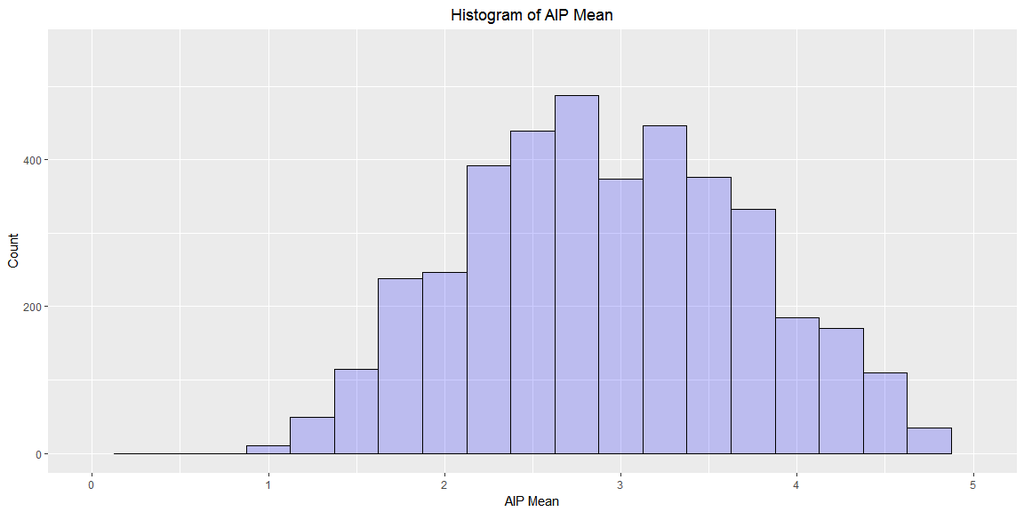

```r
# Exclude all observations where the participant is under 18 years of age and 80 and over
# Removed the age group 80 and above - Provide reason
HDIMerged <- filter(HDIMerged, Age > 18) %>%
                filter(Age < 79 )

# Histogram for AIPMean
ggplot(data=HDIMerged, aes(x=HDIMerged$AIPMean)) +
  geom_histogram(binwidth = .25,
                 col="black",
                 fill="blue",
                 alpha = .2) +
  labs(title="Histogram of AIP Mean", x="AIP Mean", y="Count") +
  xlim(c(0,5)) +
  ylim(c(0,550)) +
  theme(plot.title = element_text(hjust = 0.5, vjust=0.5))
```

**—————————————————————————————————————————————————————————————————**

**THE DISTRIBUTION OF THE AIP MEAN OF THE SURVEYED PARTICIPANTS**

- The distribution has some appearance of a bi-modal distribution but it fits a normal distribution well.

**—————————————————————————————————————————————————————————————————**

**HISTOGRAM: GP MEAN**

**—————————————————————————————————————————————————————————————————**

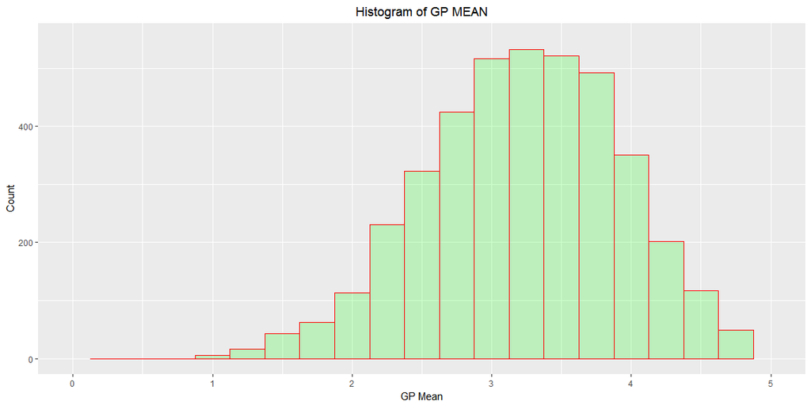

```r
# Histogram for GPMean
ggplot(data=HDIMerged, aes(x=HDIMerged$GPMean)) +
  geom_histogram(binwidth = .25,
                 col="red",
                 fill="green",
                 alpha = .2) +
  labs(title="Histogram of GP MEAN", x="GP Mean", y="Count") +
  xlim(c(0,5)) +
  ylim(c(0,550)) +
  theme(plot.title = element_text(hjust = 0.5, vjust=0.5))
```

**—————————————————————————————————————————————————————————————————**

**THE DISTRIBUTION OF THE GP MEAN OF THE SURVEYED PARTICIPANTS**

- The distribution for the for the GP mean has some left skew but still conforms to a normal distribution.

**—————————————————————————————————————————————————————————————————**

```r
# Gender Frequency
GenderFreq <- sqldf("select Gender as 'GENDER', count(1) as 'COUNT'
                      from HDIMerged
                      Group by Gender
                      Order by 2 desc")

# Table to display gender frequency
kable(GenderFreq, "html") %>%
kable_styling("striped", full_width = F, position = "left" ) %>%
column_spec(2, bold = T) %>%
row_spec(3, bold = T, color = "white", background = "#D7261E")
```

| GENDER | COUNT |
| --- | --- |
| Female | 2295 |
| Male | 1708 |
| *Missing* | 6 |

**—————————————————————————————————————————————————————————————————**

**DEMOGRAPHICS OF POLLED RESPONDENTS: MEAN AGE ~ 37 yrs.**

| DATA FRAME | COUNT | PERCENT |
| --- | --- | --- |
| FEMALE | **2295** | **57%** |
| MALE | **1708** | **43%** |

**—————————————————————————————————————————————————————————————————**

```r
# WorkStatus frequency
WrkStatusFreq <- sqldf("select WrkStatus as 'WORK STATUS', count(1) as 'COUNT'
                        from HDIMerged
                        Group by WrkStatus
                        Order by 2 desc")

# Table to display work status frequency
kable(WrkStatusFreq, "html") %>%
kable_styling("striped", full_width = F, position = "left" ) %>%
column_spec(2, bold = T) %>%
row_spec(6, bold = T, color = "white", background = "#D7261E")
```

| WORK STATUS | COUNT |
| --- | --- |
| Full-Time | 2259 |
| Student | 837 |
| Part-Time | 463 |
| Unemployed | 257 |
| Retired | 151 |
| *Missing* | 42 |

**—————————————————————————————————————————————————————————————————**

**THE FREQUENCY DISTRIBUTION OF THE WORK STATUS OF THE PARTICIPANTS IS:**

| WORK TYPE | COUNT | PERCENT |
| --- | --- | --- |
| FULL-TIME | **2259** | **56** |
| STUDENT | **837** | **21%** |
| PART-TIME | **463** | **12%** |
| UNEMPLOYED | **257** | **6%** |
| RETIRED | **151** | **4%** |
| *MISSING* | **42** | **1%** |

**—————————————————————————————————————————————————————————————————**

```r
# data set of participants grouped by country
Country <- sqldf ("select Country, Count(1) as Participants
                    from HDIMerged
                    Where Country<>'*Missing*'
                    Group by Country
                    Order by 2 desc")

# formatting the dataset to arrange the data in 6 columns
Country1 <- Country[1:30,]
Country2 <- Country[31:60,]
Country3 <- Country[61:90,]
CountryCount <- cbind(Country1, Country2,Country3)
```

**—————————————————————————————————————————————————————————————————**

- *US is 72% of the sample population surveyed. The Top 8 countries account for ~ 90% of survey respondents.*

**—————————————————————————————————————————————————————————————————**

```r
# A table of the participants by country
kable(CountryCount, "html") %>%
kable_styling("striped", full_width = F, position = "center" ) %>%
column_spec(c(2,4,6), bold = T, background = "lightblue")
```

| Country | Participants | Country | Participants | Country | Participants |
| --- | --- | --- | --- | --- | --- |
| United States | 2767 | Poland | 5 | Bahamas | 1 |
| Canada | 243 | Romania | 5 | Barbados | 1 |
| United Kingdom | 177 | Chile | 4 | Bolivia | 1 |
| Australia | 99 | Croatia | 4 | Botswana | 1 |
| India | 78 | Malaysia | 4 | Cyprus | 1 |
| Italy | 60 | Singapore | 4 | Dominican Republic | 1 |
| Germany | 36 | Afghanistan | 3 | Egypt | 1 |
| Brazil | 20 | Algeria | 3 | El Salvador | 1 |
| Ireland | 19 | Argentina | 3 | Guam | 1 |
| Israel | 19 | Austria | 3 | Guyana | 1 |
| Netherlands | 18 | Czech Republic | 3 | Hungary | 1 |
| Sweden | 15 | Ecuador | 3 | Iceland | 1 |
| Norway | 14 | Puerto Rico | 3 | Jamaica | 1 |
| France | 13 | Uruguay | 3 | Kenya | 1 |
| Japan | 13 | Albania | 2 | Lithuania | 1 |
| Spain | 13 | Bermuda | 2 | Luxembourg | 1 |
| China | 12 | Bulgaria | 2 | Macao | 1 |
| Finland | 12 | Colombia | 2 | Macedonia | 1 |
| New Zealand | 12 | Ghana | 2 | Morocco | 1 |
| South Africa | 12 | Iran | 2 | Myanmar | 1 |
| Mexico | 11 | Malta | 2 | Nicaragua | 1 |
| Philippines | 11 | Peru | 2 | Pakistan | 1 |
| Switzerland | 11 | Saudi Arabia | 2 | Panama | 1 |
| Greece | 10 | South Korea | 2 | Qatar | 1 |
| Belgium | 9 | Thailand | 2 | Russia | 1 |
| Denmark | 9 | Ukraine | 2 | Sri Lanka | 1 |
| Turkey | 9 | Venezuela | 2 | Taiwan | 1 |
| Hong Kong | 7 | Yugoslavia | 2 | Vietnam | 1 |
| Portugal | 7 | Andorra | 1 | NA | NA |
| Slovenia | 6 | Antigua | 1 | NA | NA |

```r
# Matches of how many people had others that agreed with their perceptions
Matched <- sqldf ("select Count(1) as 'MATCHES'
                    from HDIMerged
                    Where SelfProcrast=OthrProcrast
                    ")

Matched
```

```
##   MATCHES
## 1    2826
```

**—————————————————————————————————————————————————————————————————**

- THERE ARE **2826** PERSONS THAT MATCHED THEIR PERCEPTIONS TO OTHERS.
- THESE ARE PEOPLE THAT SAID THEY FELT THEY WERE OR WERE NOT PROCRASTINATORS AND OTHERS AGREED WITH THEIR ASSESSMENT.

**—————————————————————————————————————————————————————————————————**

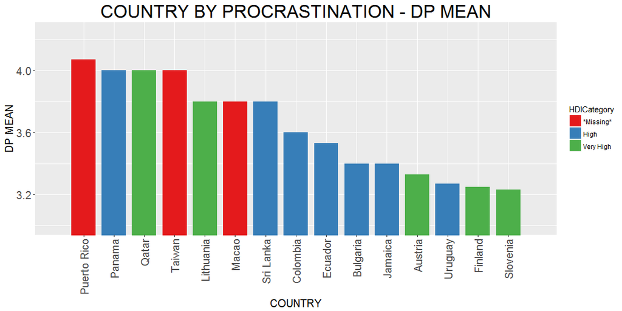

```r
#### Question 5 - Deeper Analysis ##################################

# Create a bargraph of top 15 countries colored by HDI Category

# Aggregate the average DP Mean by country
DPMeanByCountry <- select(HDIMerged, Country, DPMean) %>%
                  filter(Country!="*Missing*") %>%
                  aggregate(DPMean ~ Country, .,mean)

# Distinct list of Country and HDI category
HDICategoryByCountry <- distinct(select(HDIMerged, Country, HDICategory))

# Merge the aggregate of DPMean and the distinct country and HDI category
Top15ProcrastinatorsDP <- merge(DPMeanByCountry, HDICategoryByCountry, by = "Country", all.x = TRUE) %>%
                            arrange(desc(DPMean)) %>%
                            slice(1:15)

# Top 15 nations with their HDI scores for DP
Top15DPWithHDI <- merge(Top15ProcrastinatorsDP, HDI_raw, by = "Country", all.x = TRUE) %>%
                        select(Country, DPMean, HDI) %>%
                            arrange(desc(DPMean)) %>%
                            slice(1:15)

# Round the aggregated mean to 2 decimal places
Top15ProcrastinatorsDP$DPMean <- round(Top15ProcrastinatorsDP$DPMean, digits=2)

# Bar graph using GGPLOT for Top 15 countries in descending order for DP mean
ggplot(Top15ProcrastinatorsDP,aes(x=reorder(Country,-DPMean),y=DPMean, fill=HDICategory))+
  geom_bar(stat="identity", width=0.8, position = position_dodge(width=1))+
  coord_cartesian(xlim = c(0,16), ylim = c(3, 4.25))+
  xlab("COUNTRY") +
  ylab("DP MEAN") +
  ggtitle("COUNTRY BY PROCRASTINATION - DP MEAN")+
  theme(axis.text.x = element_text(size=15, angle = 90, hjust = 1, vjust = 0.5),
        axis.text.y = element_text(size=15, angle = 0, hjust = 1, vjust = 0.5),
        axis.title=element_text(size=15),
  plot.title = element_text(size=25, hjust = 0.5, vjust = 1)) +
  scale_fill_brewer(palette="Set1")
```

**—————————————————————————————————————————————————————————————————**

**THE TOP 15 COUNTRIES WITH THE HIGHEST DP MEAN ARE:** - Puerto Rico - Panama - Qatar - Taiwan - Lithuania - Macao - Sri Lanka - Colombia - Ecuador - Bulgaria - Jamaica - Austria - Uruguay - Finland - Slovenia

**—————————————————————————————————————————————————————————————————**

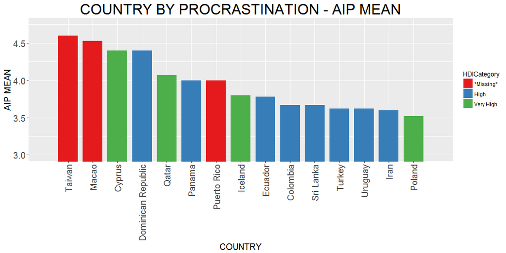

```r
#TOP 15 nations with average procrastination scores
# 5c

# Aggregate the average AIP Mean by country
AIPMeanByCountry <- select(HDIMerged, Country, AIPMean) %>%
                  filter(Country!="*Missing*") %>%
                  aggregate(AIPMean ~ Country, .,mean)

# Distinct list of Country and HDI category
HDICategoryByCountry <- distinct(select(HDIMerged, Country, HDICategory))

# Merge the aggregate of DPMean and the distinct country and HDI category
Top15ProcrastinatorsAIP <- merge(AIPMeanByCountry, HDICategoryByCountry, by = "Country", all.x = TRUE) %>%
                            arrange(desc(AIPMean)) %>%
                            slice(1:15)

# Top 15 nations with their HDI scores for AIP
Top15AIPWithHDI <- merge(Top15ProcrastinatorsAIP, HDI_raw, by = "Country", all.x = TRUE) %>%
                        select(Country, AIPMean, HDI) %>%
                            arrange(desc(AIPMean)) %>%
                            slice(1:15)

# Round the aggregated mean to 2 decimal places
Top15ProcrastinatorsAIP$AIPMean <- round(Top15ProcrastinatorsAIP$AIPMean, digits=2)


# Bar graph using GGPLOT for Top 15 countries in descending order for AIP mean
ggplot(Top15ProcrastinatorsAIP,aes(x=reorder(Country,-AIPMean),y=AIPMean, fill=HDICategory))+
  geom_bar(stat="identity", width=0.8, position = position_dodge(width=1))+
  coord_cartesian(xlim = c(0,16), ylim = c(3, 4.75))+
  xlab("COUNTRY") +
  ylab("AIP MEAN") +
  ggtitle("COUNTRY BY PROCRASTINATION - AIP MEAN")+
  theme(plot.title = element_text(hjust = 0.5)) +
  theme(axis.text.x = element_text(size=15, angle = 90, hjust = 1, vjust = 0.5),
        axis.text.y = element_text(size=15, angle = 0, hjust = 1, vjust = 0.5),
        axis.title=element_text(size=15),
  plot.title = element_text(size=25, hjust = 0.5, vjust = 1)) +
  scale_fill_brewer(palette="Set1")
```

**—————————————————————————————————————————————————————————————————**

**THE TOP 15 COUNTRIES WITH THE HIGHEST AIP MEAN ARE:** - Taiwan - Macao - Cyprus - Dominican Republic - Qatar - Panama - Puerto Rico - Iceland - Ecuador - Colombia - Sri Lanka - Turkey - Uruguay - Iran - Poland

**—————————————————————————————————————————————————————————————————**

**THE COUNTRIES THAT ARE BOTH IN TOP 15 WITH THE HIGHEST DP MEAN AND AIP MEAN ARE:**

- Taiwan
- Macao
- Qatar
- Panama
- Puerto Rico
- Ecuador
- Colombia
- Sri Lanka
- Uruguay

*Ecuador and Uruguay also have the same rank on both scales.*

**—————————————————————————————————————————————————————————————————**

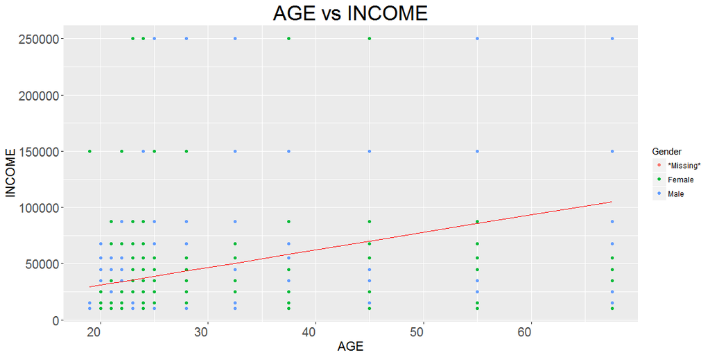

```r
################# 5D ##################################
# Create a data frame with age, income, and gender variables
AgeIncomeGender <- sqldf("select Age, Income, Gender
                          From HDIMerged
                          Where Income <> 'NA'")

# Regress Income on Age
mylm <- lm(Income ~ Age, data=AgeIncomeGender)

# Plot of Income vs Age
  ggplot(AgeIncomeGender, aes(x=Age, y=Income, colour=Gender)) +
  geom_point() +
  geom_line(colour="red",aes(y=fitted(mylm)))+
  xlab("AGE") +
  ylab("INCOME") +
  ggtitle("AGE vs INCOME")+
  theme(plot.title = element_text(hjust = 0.5)) +
  theme(axis.text.x = element_text(size=15, angle = 0, hjust = 1, vjust = 0.5),
        axis.text.y = element_text(size=15, angle = 0, hjust = 1, vjust = 0.5),
        axis.title=element_text(size=15),
  plot.title = element_text(size=25, hjust = 0.5, vjust = 1)) +
  scale_fill_brewer(palette="Set1")
```

**—————————————————————————————————————————————————————————————————**

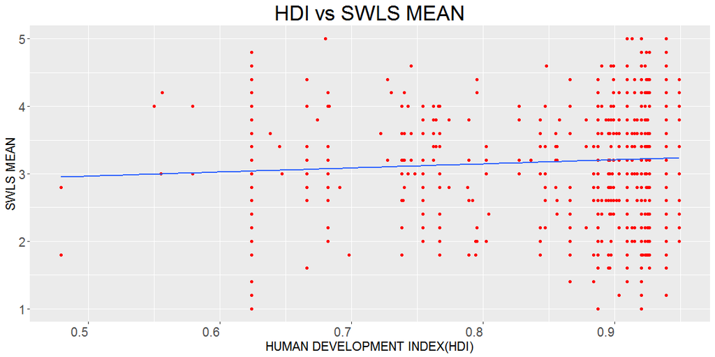

```r
################# 5E ##################################
# Create a data frame with age, income, and gender variables
# Create a subset of data for comparing Life Satisfcation and HDI

swls_hdi <- subset(HDIMerged, select = c(SWLSMean, HDI, HDICategory)) %>%
                  filter(HDI!="*Missing*") %>%
                  arrange(desc(SWLSMean))

# Transform to numeric values
swls_hdi[, 1:2] <- sapply(swls_hdi[, 1:2], as.numeric)

# # linear regression analysis
mylm <- lm(SWLSMean ~ HDI, data=swls_hdi)

# Plot a scatter plot for age and income without log transform
# Add the regression line
ggplot(swls_hdi, aes(x=HDI, y=SWLSMean)) +
  geom_point(color="red")+
  geom_smooth(method=lm, se=FALSE) +
  xlab("HUMAN DEVELOPMENT INDEX(HDI)") +
  ylab("SWLS MEAN") +
  ggtitle("HDI vs SWLS MEAN")+
  theme(plot.title = element_text(hjust = 0.5)) +
  theme(axis.text.x = element_text(size=15, angle = 0, hjust = 1, vjust = 0.5),
        axis.text.y = element_text(size=15, angle = 0, hjust = 1, vjust = 0.5),
        axis.title=element_text(size=15),
  plot.title = element_text(size=25, hjust = 0.5, vjust = 1)) +
  scale_fill_brewer(palette="Set1")
```

**—————————————————————————————————————————————————————————————————**

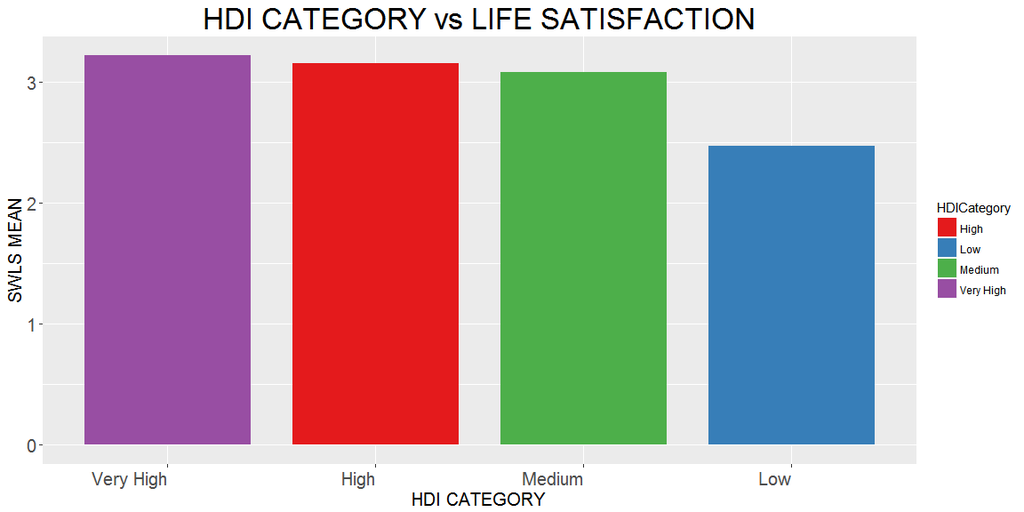

```r
# Aggregate the average AIP Mean by country
SWLSMeanByHDICategory <- select(HDIMerged, HDICategory, SWLSMean) %>%
                         filter(HDICategory!="*Missing*") %>%
                         aggregate(SWLSMean ~ HDICategory, .,mean)


# Bar graph using GGPLOT HDICategory vs Life Satisfaction
ggplot(SWLSMeanByHDICategory,aes(x=reorder(HDICategory,-SWLSMean),y=SWLSMean, fill=HDICategory))+
  geom_bar(stat="identity", width=0.8, position = position_dodge(width=1))+
  #coord_cartesian(xlim = c(0,16), ylim = c(3, 4.75))+
  xlab("HDI CATEGORY") +
  ylab("SWLS MEAN") +
  ggtitle("HDI CATEGORY vs LIFE SATISFACTION")+
  theme(plot.title = element_text(hjust = 0.5)) +
  theme(axis.text.x = element_text(size=15, angle = 0, hjust = 1, vjust = 0.5),
        axis.text.y = element_text(size=15, angle = 0, hjust = 1, vjust = 0.5),
        axis.title=element_text(size=15),
  plot.title = element_text(size=25, hjust = 0.5, vjust = 1)) +
  scale_fill_brewer(palette="Set1")
```

```r
# Log transform income to see whether it changes the relationship, it does not
# swls_hdi[, 2] <- log(swls_hdi[2],2)
```

**—————————————————————————————————————————————————————————————————**

```r
# Create a new data.frame with columns rearranged with the CLEAN data
ProcrastinateClean <- select(HDIMerged,
                            Age,
                            Gender,
                            Kids,
                            Education,
                            EducationAlt,
                            WrkStatus,
                            Income,
                            Occupation,
                            OccupatnAlt,
                            YearsInPos,
                            MnthsInPos,
                            CommSize,
                            Country,
                            MaritalStat,
                            Sons,
                            Daughters,
                            SelfProcrast,
                            OthrProcrast,
                            HDICategory,
                            DPMean,
                            AIPMean,
                            GPMean,
                            SWLSMean,
                            DP1,
                            DP2,
                            DP3,
                            DP4,
                            DP5,
                            AIP1,
                            AIP2,
                            AIP3,
                            AIP4,
                            AIP5,
                            AIP6,
                            AIP7,
                            AIP8,
                            AIP9,
                            AIP10,
                            AIP11,
                            AIP12,
                            AIP13,
                            AIP14,
                            AIP15,
                            GP1,
                            GP2,
                            GP3,
                            GP4,
                            GP5,
                            GP6,
                            GP7,
                            GP8,
                            GP9,
                            GP10,
                            GP11,
                            GP12,
                            GP13,
                            GP14,
                            GP15,
                            GP16,
                            GP17,
                            GP18,
                            GP19,
                            GP20,
                            SWLS1,
                            SWLS2,
                            SWLS3,
                            SWLS4,
                            SWLS5)
```

**—————————————————————————————————————————————————————————————————**

CLIENT DATA FILES ARE IN THE “DATA” FOLDER IN THE REPOSITORY

**—————————————————————————————————————————————————————————————————**

```r
# Write csv files to present to client

# write.csv(ProcrastinateClean, file = "ProcrastinationCLEAN.csv", row.names=FALSE )
# write.csv(procrastinate_raw,  file = "ProcrastinationRAW.csv"  , row.names=FALSE )
# write.csv(HDIMerged, file = "HDI_Merged_Data.csv", row.names=FALSE )
# write.csv(HDI_raw,   file = "HDI_Data.csv", row.names=FALSE )
# write.csv(Top15AIPWithHDI,   file = "Top15CoountriesAIP_HDI.csv", row.names=FALSE )
# write.csv(Top15DPWithHDI,   file = "Top15CoountriesDP_HDI.csv", row.names=FALSE )
```

**—————————————————————————————————————————————————————————————————**

## SUMMARY

This study focuses on the procrastination behaviors of a wide spectrum of regions and demographic behavior. As the United States is the leading polled country, it can be inferred (assumption we are making assuming that we actually conducted the survey on behalf of the client) that this is a representative view of the US procrastination behavior.

THANK YOU FOR THIS OPPORTUNITY TO ANALYZE YOUR DATA AND PRESENT OUR FINDINGS.

CONTACT INFORMATION: **GLOBAL CONSULTANCY, INC.**

RUHAAB MARKAS rmarkas@mail.smu.edu Tel: 1 (789)647 4563

KEVIN MENDONSA kmendonsa@mail.smu.edu Tel: 1(714)945 5874

**—————————————————————————————————————————————————————————————————**